# Exploring data from a wholesale distributor in order to perform market segmentation of clients using their spending habits.

Ketan Bhadoriya

###### Note : Data Taken from Datacamp.com from Cluster Analysis Course in R and Case Study performed under the guidance of the Tutor Dima Gorenshteyn.

### Loading the Data and Required Packages

```r
library(dplyr)
library(ggplot2)
library(tidyr)
library(dendextend)
library(cluster)
library(purrr)

customers_spend <- readRDS("ws_customers.rds")
head(customers_spend)
```

```
##    Milk Grocery Frozen
## 1 11103   12469    902
## 2  2013    6550    909
## 3  1897    5234    417
## 4  1304    3643   3045
## 5  3199    6986   1455
## 6  4560    9965    934
```

```r
tail(customers_spend)
```

```
##    Milk Grocery Frozen
## 40  928    2743  11559
## 41 6817   10790   1365
## 42 1511    1330    650
## 43 1347    2611   8170
## 44  333    7021  15601
## 45 1188    5332   9584
```

### Using Hierarchical Clustering to Perform Market Segmentation

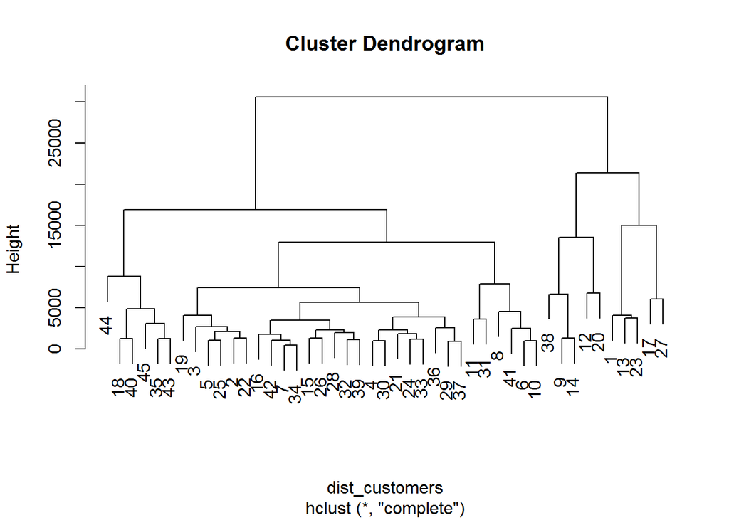

```r
#Calculating euclidean distance between customers

dist_customers <- dist(customers_spend,method="euclidean")


#Generating a complete linkage analysis
hc_customers <- hclust(dist_customers,method="complete")

#Plotting the dendrogram
plot(hc_customers)
```

```r
#Create=ing a cluster assignment vector at h = 15000
clust_customers <- cutree(hc_customers,h=15000)

#Generating the segmented customers dataframe
segment_customers <- mutate(customers_spend, cluster = clust_customers)
```

### Exploring Wholesale Customers Clusters

```r
#Counting the number of customers that fall into each cluster

clusters_size <- count(segment_customers, cluster)
clusters_size
```

```
## # A tibble: 4 x 2
##   cluster     n
##     <int> <int>
## 1       1     5
## 2       2    29
## 3       3     5
## 4       4     6
```

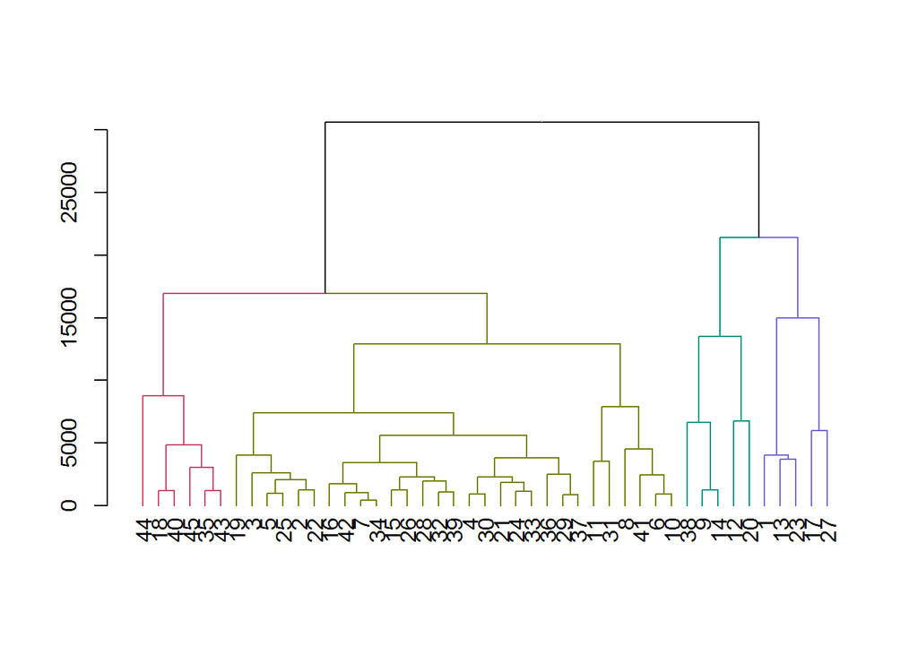

```r
#Colored dendrogram based on the height cutoff

dend_customers <- as.dendrogram(hc_customers)
dend_colored <- color_branches(dend_customers, h = 15000)

#Plotting the colored dendrogram

plot(dend_colored)
```

```r
#Calculating the mean for each category
str(segment_customers)
```

```
## 'data.frame':    45 obs. of  4 variables:
##  $ Milk   : int  11103 2013 1897 1304 3199 4560 879 6243 13316 5302 ...
##  $ Grocery: int  12469 6550 5234 3643 6986 9965 2060 6360 20399 9785 ...
##  $ Frozen : int  902 909 417 3045 1455 934 264 824 1809 364 ...
##  $ cluster: int  1 2 2 2 2 2 2 2 3 2 ...
```

```r
final_segmented_customers<- segment_customers %>%
                                  group_by(cluster) %>%
                                  summarize("Milk"=as.integer(mean(Milk)),
                                      "Grocery"=as.integer(mean(Grocery)),
                                       "Frozen"=as.integer(mean(Frozen)))

final_segmented_customers$Cluster_Size <- clusters_size$n

final_segmented_customers
```

```
## # A tibble: 4 x 5
##   cluster  Milk Grocery Frozen Cluster_Size
##     <int> <int>   <int>  <int>        <int>
## 1       1 16950   12891    991            5
## 2       2  2512    5228   1795           29
## 3       3 10452   22550   1354            5
## 4       4  1249    3916  10888            6
```

### Performing the same analysis using k-Means Clustering

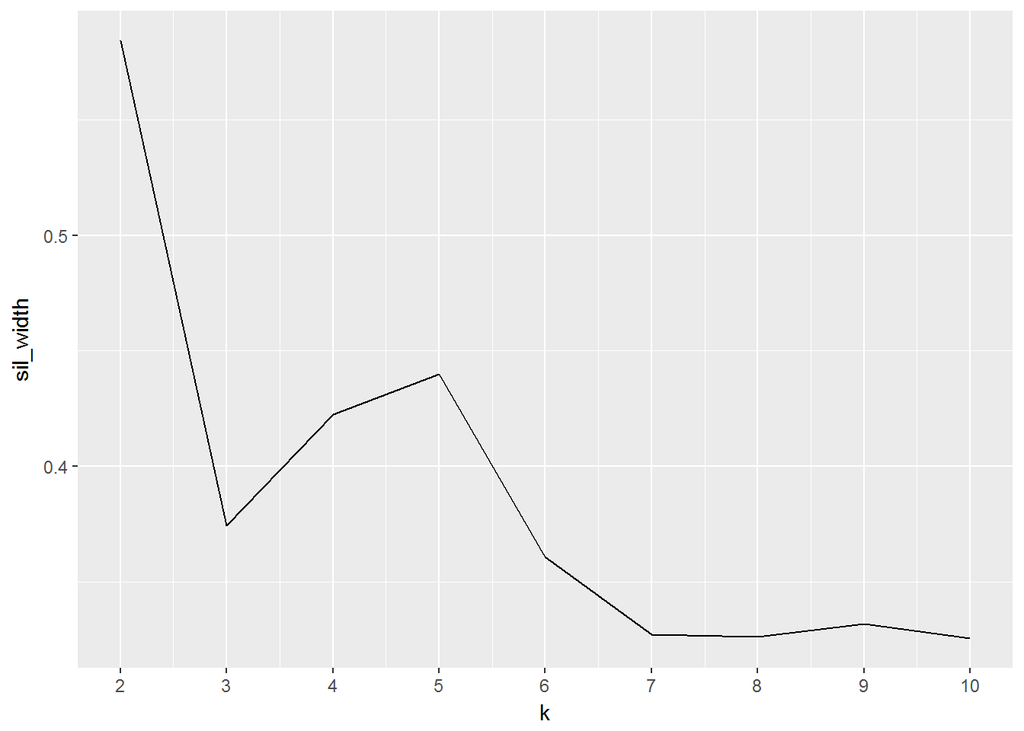

```r
#Determining the "best" value of k using average silhouette width.

#Using map_dbl to run many models with varying value of k

sil_width <- map_dbl(2:10,  function(k){
  model <- pam(x = customers_spend, k = k)
  model$silinfo$avg.width
})

#Generating a data frame containing both k and sil_width

sil_df <- data.frame(
  k = 2:10,
  sil_width = sil_width
)

#Plotting the relationship between k and sil_width

ggplot(sil_df, aes(x = k, y = sil_width)) +
  geom_line() +
  scale_x_continuous(breaks = 2:10)
```

*Comment : From the elbow plot it is noticed that k = 2 has the highest average sillhouette width and is the “best” value of k we will move forward with.*

### Analyzing the wholesale customer data by building and exploring a kmeans model with 2 clusters

```r
#Building a k-means model for the customers_spend with a k of 2

model_customers_k <- kmeans(x=customers_spend,centers=2)

#Extracting the vector of cluster assignments from the model

clust_customers_k <- model_customers_k$cluster

#Build the segment_customers dataframe

segment_customers_k <- mutate(customers_spend, cluster = clust_customers_k)

#Calculating the size of each cluster

clusters_size_k <- count(segment_customers_k, cluster)

# Calculate the mean for each category
str(segment_customers_k)
```

```
## 'data.frame':    45 obs. of  4 variables:
##  $ Milk   : int  11103 2013 1897 1304 3199 4560 879 6243 13316 5302 ...
##  $ Grocery: int  12469 6550 5234 3643 6986 9965 2060 6360 20399 9785 ...
##  $ Frozen : int  902 909 417 3045 1455 934 264 824 1809 364 ...
##  $ cluster: int  2 1 1 1 1 1 1 1 2 1 ...
```

```r
final_segmented_customers_k<- segment_customers_k %>%
                                  group_by(cluster) %>%
                                  summarize("Milk"=as.integer(mean(Milk)),
                                            "Grocery"=as.integer(mean(Grocery)),
                                            "Frozen"=as.integer(mean(Frozen)))

final_segmented_customers_k$Cluster_Size <- clusters_size_k$n

final_segmented_customers_k #K-Means Clustering
```

```
## # A tibble: 2 x 5
##   cluster  Milk Grocery Frozen Cluster_Size
##     <int> <int>   <int>  <int>        <int>
## 1       1  2296    5004   3354           35
## 2       2 13701   17721   1173           10
```

```r
final_segmented_customers #Hierarchical Clustering
```

```
## # A tibble: 4 x 5
##   cluster  Milk Grocery Frozen Cluster_Size
##     <int> <int>   <int>  <int>        <int>
## 1       1 16950   12891    991            5
## 2       2  2512    5228   1795           29
## 3       3 10452   22550   1354            5
## 4       4  1249    3916  10888            6
```

### Conclusion

> “Hierarchical Clustering Reulted in Four Clusters”
- Customers in cluster 1 spent more money on Milk than any other cluster
- Customers in cluster 3 spent more money on Grocery than any other cluster
- Customers in cluster 4 spent more money on Frozen goods than any other cluster
- The majority of customers fell into cluster 2 and did not show any excessive spending in any category